# ETL Lending CLub

# Visualizando distribuição do objetivo do empréstimo por quitação do mesmo

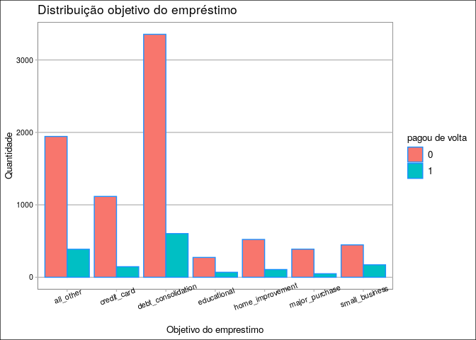

```r
ggplot(df, aes(x=df$`objetivo do emprestimo`, fill=`pagou de volta`)) + geom_bar(position = "dodge", color="dodgerblue") +
labs(x="Objetivo do emprestimo", title = "Distribuição objetivo do empréstimo", y="Quantidade") +
theme_calc() + theme(axis.text.x = element_text(angle = 20))
```

**Obs:** A maioria das dívidas são por consolidação de débito

# Visualizando pontuação de crédito baseado na taxa de juros

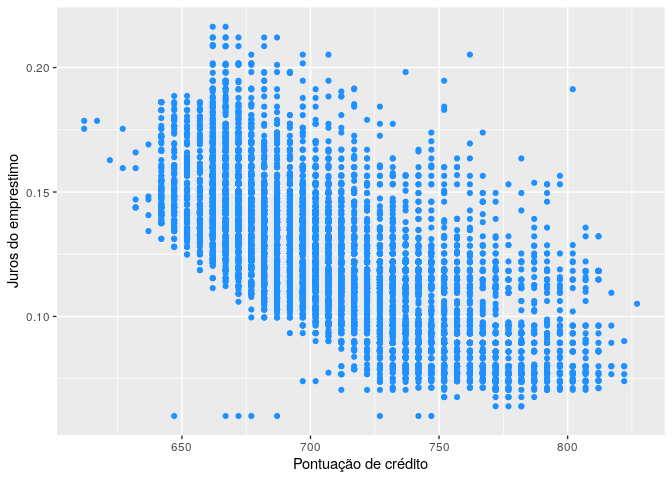

```r
ggplot(df, aes(x=df$`pontuacao de credito`, y=df$`juros do emprestimo`)) + geom_point(color="dodgerblue")  +
labs(x="Pontuação de crédito", y="Juros do emprestimo")
```

**Obs:** É notável que a taxa de juros aumenta quando a pontuação do cliente tende a cair

# Taxa de juros do empréstimo baseado na renda anual do cliente

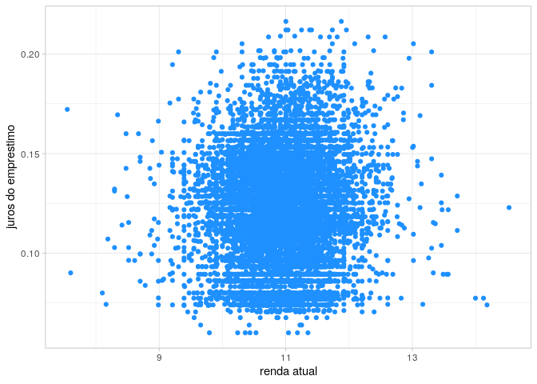

```r
ggplot(df, aes(df$`renda anual`, y=df$`juros do emprestimo`)) + geom_point(color="dodgerblue") +
labs(x="renda atual", y="juros do emprestimo") + theme_light()
```

**Obs:** É notável que a grande maioria dos clientes tem uma renda próxima a 11 mil por ano, e essa grande maioria paga uma taxa entre 10 a 16%

# agrupando média de quantidade de consultorias que o cliente teve durante o semestre por quitação de dívidas

```r
df %>% group_by(`pagou de volta`) %>% summarise("media consultas em 6 meses"=mean(`qtd consultas em seis meses`)) %>% knitr::kable()
```

| pagou de volta | media consultas em 6 meses |
| --- | --- |
| 0 | 1.433934 |
| 1 | 2.330724 |

**OBs:** Em média, quem tem mais consultas durante o semestre tende a pagar suas dívidas

# Agrupando média de pontuação no lending club por quitação de dívidas

```r
df %>% group_by(`pagou de volta`) %>% summarise("Media de pontuacao"=mean(`pontuacao de credito`)) %>% knitr::kable()
```

| pagou de volta | Media de pontuacao |
| --- | --- |
| 0 | 713.3269 |
| 1 | 697.8284 |

**Obs:** assim como no gráfico, foi confirmado que a pontuação nao é fator determinante para a quitação da dívida